# Aplicaciones del modelo de regresión lineal: cálculo de predicciones

# 1 Aplicaciones de la regresión

Podemos identificar dos aplicaciones básicas de los modelos de regresión:

- Predecir.
- Describir relaciones entre variables.

La predicción en el modelo de regresión se puede enfocar de dos formas diferentes

- Estimación del valor medio y su intervalo de confianza.
- Intervalo de predicción.

# 2 Estimación del valor medio

Sea el modelo de regresión

$$y_i = \beta_0 + \beta_1 x_{1i} + \beta_2 x_{2i} + \cdots + \beta_k
x_{ki} + u_i, \ i = 1,2,\cdots,n$$

Este modelo se puede escribir como:

$$y_i =
\begin{bmatrix}
1 & x_{1i} & x_{2i} & \cdots & x_{ki}
\end{bmatrix}
\begin{bmatrix}
\beta_0 \\ \beta_1 \\ \beta_2 \\ \cdots \\ \beta_k
\end{bmatrix}
+ u_i
=
x_i^T \beta + u_i, \ i = 1,2,\cdots,n$$

Por ejemplo, si consideramos los valores de los regresores $x_p^T = [1 \ x_{1p} \ x_{2p} \ \cdots \ x_{kp}]$, se tiene que cumplir que

$$y_p = x_p^T \beta + u_p, \quad u_p \sim N(0,\sigma^2)$$

El valor medio de $y_p$ es:

$$E[y_p] = E[x_p^T \beta + u_p] = x_p^T \beta$$

Por este motivo es usual utilizar el siguiente estimador de $E[y_p]$:

$$\hat y_p = x_p^T \hat \beta$$

es decir, sustituimos $\beta$ por sus estimadores. Este valor es un estimador centrado de $E[y_p]$:

$$E[\hat y_p] = E[x_p^T \hat \beta] = x_p^T E[\hat \beta] = x_p^T \beta$$

En la práctica, cuando se habla de predecir el valor de $y$ en el punto $x_p$ lo que se hace es estimar el valor medio de $y_p$, es decir, $\hat y_p$.

# 3 Varianza de la estimación del valor medio

## 3.1 Con matrices de datos

La varianza se calcula como:

$$Var[\hat y_p] = Var[x_p^T \hat \beta] = x_p^T Var[\hat \beta] x_p =
\sigma^2 x_p^T (X^TX)^{-1} x_p = \sigma^2 v_p$$

donde

$$v_p = x_p^T (X^TX)^{-1} x_p$$

## 3.2 Con matrices de covarianzas

Se tiene que

$$\hat y_p = x_p^T \hat \beta = \hat \beta_0 +
\begin{bmatrix}
x_{1p} & x_{2p} & \cdots & x_{kp}
\end{bmatrix}
\begin{bmatrix}
\hat \beta_1 \\ \hat \beta_2 \\ \cdots \\ \hat \beta_k
\end{bmatrix}
=
\hat \beta_0 + \tilde x_p^T \hat \beta_a$$

donde $\tilde{x}_p^T = [\ x_{1p} \ x_{2p} \ \cdots \ x_{kp}]$. Por otro lado hemos visto que

$$\bar y = \beta_0 + \beta_1 \bar x_{1} + \beta_2 \bar x_{2} + \cdots +
\beta_k \bar x_{k} = \hat \beta_0 + \bar x^T \hat \beta_a$$

donde $\bar x^T = [\bar x_{1} \ \bar x_{2} \ \cdots \ \bar x_{k}]$. Despejando $\hat \beta_0$ y sustituyendo en la otra ecuación se obtiene

$$\hat y_p = \bar y + (\tilde x_p - \bar x)^T \hat \beta_a$$

Por tanto:

$$Var[\hat y_p] = Var[\bar y] + (\tilde x_p - \bar x)^T Var[\hat \beta_a]
(\tilde x_p - \bar x)$$

En los temas anteriores se ha visto que $Var[\bar y] = \frac{\sigma^2}{n}$ y que $Var[\hat \beta_a] = \frac{\sigma^2}{n-1} S_{XX}^{-1}$. Por tanto:

$$Var[\hat y_p] = \frac{\sigma^2}{n} + \frac{\sigma^2}{n-1} (\tilde x_p -
\bar x)^T S_{XX}^{-1} (\tilde x_p - \bar x) = \sigma^2 v_p$$

donde en este caso

$$v_p = \frac{1}{n} + \frac{1}{n-1} (\tilde x_p - \bar x)^T S_{XX}^{-1}
(\tilde x_p - \bar x)$$

# 4 Intervalo de confianza de la estimación del valor medio

Primero vamos a deducir la distribución de $\hat y_p = x_p^T \hat \beta$. Como $\hat \beta$ tiene distribución normal, se tiene que:

$$\hat y_p \sim N(x_p^T \beta, \sigma^2 v_p) \Rightarrow \frac{\hat y_p -
x_p^T \beta}{se(\hat y_p)} \sim t_{n-k-1}$$

donde $se(\hat y_p) = \hat s_R\sqrt{v_p}$. Finalmente, el intervalo de confianza para $E[y_p] = x_p^T \beta$ es:

$$\hat y_p - t_{\alpha/2} se(\hat y_p) \leq E[y_p] \leq \hat y_p +
t_{\alpha/2} se(\hat y_p)$$

Recordad que los intervalos de confianza se definen para parámetros del modelo. En este caso el intervalo de confianza se ha definido para una combinación lineal de parámetros.

# 5 Intervalo de predicción

También podemos decir algo acerca de la predicción de $y_p$, y no solo de su valor medio. Como $y_p = x_p^T \beta + u_p$, donde $u_p \sim N(0,\sigma^2)$, se tiene que:

$$y_p \sim N(x_p^T \beta, \sigma^2)$$

Nos gustaría construir un intervalo $(a,b)$ para $y_p$ tal que:

$$P(a \leq y_p \leq b) = 1-\alpha$$

Sin embargo no podemos utilizar la distribución de $y_p$ ya que desconocemos $\beta$ y $\sigma^2$. La opción es trabajar con la diferencia entre $y_p$ y su valor medio predicho $\hat{y}_p$. Hemos visto que

$$\hat y_p \sim N(x_p^T \beta, \sigma^2 v_p)$$

Por tanto podemos calcular la distribución de $y_p - \hat y_p$:

$$y_p - \hat y_p \sim N(0, \sigma^2(1 + v_p))$$

ya que:

$$E[y_p - \hat y_p] = E[y_p] - E[\hat y_p] = x_p^T \beta - x_p^T \beta = 0$$

$$Var[y_p - \hat y_p] = Var[y_p] + Var[\hat y_p] = \sigma^2 + \sigma^2
v_p= \sigma^2 (1 + v_p)$$

donde se ha considerado que $y_p$ e $\hat y_p$ son independientes. Utilizando la varianza residual tenemos:

$$\frac{y_p - \hat y_p}{\hat s_R\sqrt{1 + v_p}} \sim t_{n-k-1}$$

Con lo que se puede encontrar que:

$$P \left( - t_{\alpha/2} \hat s_R\sqrt{1 + v_p} \leq y_p - \hat y_p \leq
t_{\alpha/2} \hat s_R\sqrt{1 + v_p} \right) = 1 - \alpha$$

Finalmente, el intervalo para $y_p$ que estábamos buscando se calcula como:

$$P \left( \hat y_p - t_{\alpha/2} \hat s_R\sqrt{1 + v_p} \leq y_p \leq
\hat y_p + t_{\alpha/2} \hat s_R\sqrt{1 + v_p} \right) = 1 - \alpha$$

Esto no es un intervalo de confianza ya que $y_p$ no es un parámetro, sino que es un intervalo de probabilidad ($y_p$ es una variable aleatoria).

# 6 Conclusiones

Sea un valor para los regresores $x_p$. Según el modelo $y_p = x_p^T \beta + u_p, \ u_p \sim N(0, \sigma^2)$:

- Si queremos asignar un *valor puntual* para la predicción de $y_p$ es usual utilizar la estimación del valor medio, $\hat y_p = x_p^T \hat \beta$, que es un estimador centrado del valor medio teórico, $x_p^T \beta$. Es posible calcular un intervalo de confianza para el valor medio teórico.
- También se puede construir un intervalo para la predicción de $y_p$.

# 7 Ejemplo

```r
d = read.csv("datos/kidiq.csv")
d$mom_hs = factor(d$mom_hs, labels = c("no", "si"))
d$mom_work = factor(d$mom_work, labels = c("notrabaja", "trabaja23", "trabaja1_parcial", "trabaja1_completo"))
```

## 7.1 Predicción en un modelo de regresión simple

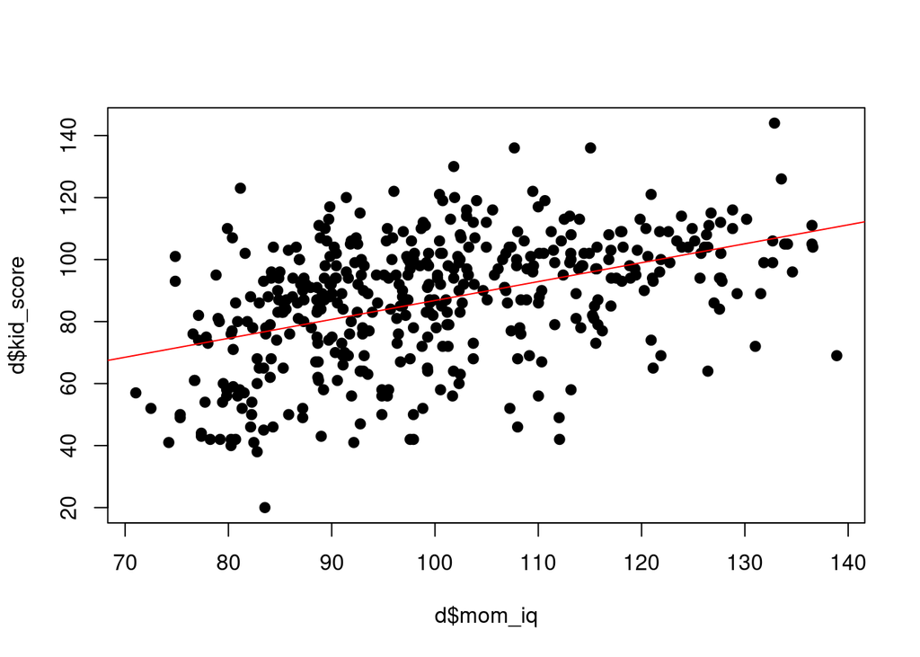

```r
m = lm(kid_score ~ mom_iq, data = d)
plot(d$mom_iq, d$kid_score, pch = 19)
abline(m, col = "red", lwd = 1)
```

### 7.1.1 Estimación del valor medio

```r
xp = matrix(c(1, 130), ncol = 1)
n = nrow(d)
beta_e = coef(m)
sR2 = sum(resid(m)^2)/(n-2)
X = model.matrix(m)
(vp = t(xp) %*% solve(t(X) %*% X) %*% xp)
```

```
##            [,1]
## [1,] 0.01154202
```

```r
# predicción puntual
(yp_medio = t(xp) %*% beta_e)
```

```
##          [,1]
## [1,] 105.0965
```

```r
# intervalo de confianza
yp_medio[1,1] + c(-1,1)*qt(0.975,n-2)*sqrt(sR2*(vp[1,1]))
```

```
## [1] 101.2394 108.9535
```

```r
# para comprobar, vamos a calcular vp con la matriz de covarianzas
Sxx = var(d$mom_iq)
xp1 = 130
xm = mean(d$mom_iq)
(vp1 = 1/n + 1/(n-1)*(xp1 - xm)^2*1/Sxx)
```

```
## [1] 0.01154202
```

En R:

```r
xp1 = data.frame(mom_iq = 130)
(yp_medio1 = predict(m, newdata = xp1, interval = "confidence", level = 0.95))
```

```
##        fit      lwr      upr
## 1 105.0965 101.2394 108.9535
```

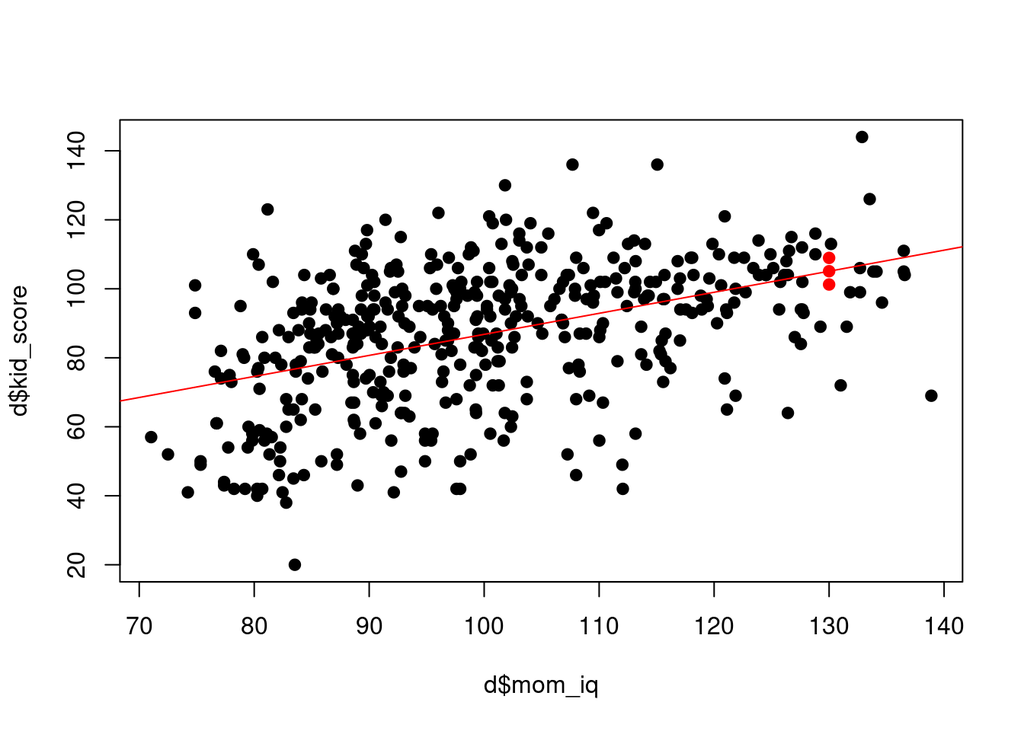

```r
plot(d$mom_iq, d$kid_score, pch = 19)
abline(m, col = "red", lwd = 1)
points(xp1$mom_iq, yp_medio1[1], col = "red", pch = 19) # prediccion puntual
points(xp1$mom_iq, yp_medio1[2], col = "red", pch = 19) # limite inferior int. conf.
points(xp1$mom_iq, yp_medio1[3], col = "red", pch = 19) # limite superior int. conf.
```

### 7.1.2 Intervalo de prediccion

```r
(yp = yp_medio[1,1] + c(-1,1)*qt(0.975,n-2)*sqrt(sR2*(1 + vp[1,1])))
```

```
## [1]  68.98835 141.20459
```

- En R:

```r
(yp1 = predict(m, newdata = xp1, interval = "prediction", level = 0.95))
```

```
##        fit      lwr      upr
## 1 105.0965 68.98835 141.2046
```

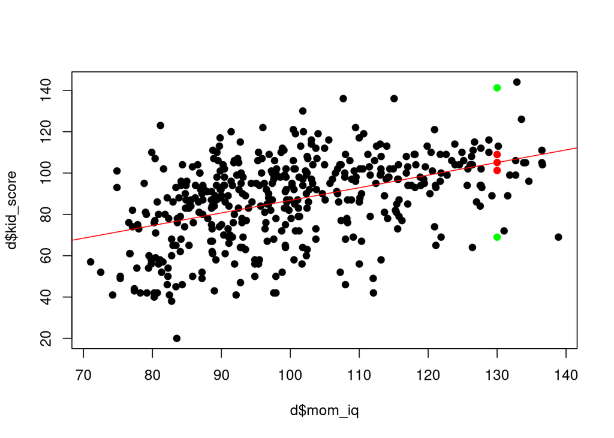

```r
plot(d$mom_iq, d$kid_score, pch = 19)
abline(m, col = "red", lwd = 1)
points(xp1$mom_iq, yp_medio1[1], col = "red", pch = 19) # prediccion puntual
points(xp1$mom_iq, yp_medio1[2], col = "red", pch = 19) # limite inferior int. conf.
points(xp1$mom_iq, yp_medio1[3], col = "red", pch = 19) # limite superior int. conf.
points(xp1$mom_iq, yp1[2], col = "green", pch = 19) # limite inferior int. pred.
points(xp1$mom_iq, yp1[3], col = "green", pch = 19) # limite superior int. pred.
```

## 7.2 Predicción en un modelo de regresión múltiple

Vamos a predecir:

- mom_iq = 130
- mon_hs = no
- mom_age = 25
- mom_work = trabaja1_parcial

```r
m2 = lm(kid_score ~ mom_iq + mom_hs + mom_age + mom_work, data = d)
summary(m2)
```

```
##
## Call:
## lm(formula = kid_score ~ mom_iq + mom_hs + mom_age + mom_work,
##     data = d)
##
## Residuals:
##     Min      1Q  Median      3Q     Max
## -54.414 -12.095   2.015  11.653  49.100
##
## Coefficients:
##                           Estimate Std. Error t value Pr(>|t|)
## (Intercept)               20.27273    9.39320   2.158   0.0315 *
## mom_iq                     0.55288    0.06138   9.008   <2e-16 ***
## mom_hssi                   5.43466    2.32518   2.337   0.0199 *
## mom_age                    0.21629    0.33351   0.649   0.5170
## mom_worktrabaja23          2.98266    2.81289   1.060   0.2896
## mom_worktrabaja1_parcial   5.48824    3.25239   1.687   0.0922 .
## mom_worktrabaja1_completo  1.41929    2.51621   0.564   0.5730
## ---
## Signif. codes:  0 '***' 0.001 '**' 0.01 '*' 0.05 '.' 0.1 ' ' 1
##
## Residual standard error: 18.14 on 427 degrees of freedom
## Multiple R-squared:  0.2213, Adjusted R-squared:  0.2103
## F-statistic: 20.22 on 6 and 427 DF,  p-value: < 2.2e-16
```

### 7.2.1 Estimación del valor medio

Recordamos que el modelo sería:

$$kid\_score = \hat \beta_0 + \hat \beta_1 mom\_iq + \hat \beta_2
mom\_hssi + \hat \beta_3 mon\_age + \hat \beta_4mom\_worktrabaja23 + \\
\hat \beta_5 mom\_worktrabaja1\_parcial + \hat \beta_6
mom\_worktrabaja1\_completo + e$$

```r
xp = matrix(c(1, 130, 0, 25, 0, 1, 0), ncol = 1)
beta_e = coef(m2)
k = 6 # numero de regresores
sR2 = sum(resid(m2)^2)/(n-k-1)
X = model.matrix(m2)
(vp = t(xp) %*% solve(t(X) %*% X) %*% xp)
```

```
##            [,1]
## [1,] 0.04191298
```

```r
# prediccion del valor medio
(yp_medio = t(xp) %*% beta_e)
```

```
##          [,1]
## [1,] 103.0423
```

```r
# intervalo de confianza
yp_medio[1,1] + c(-1,1)*qt(0.975,n-k-1)*sqrt(sR2*(vp[1,1]))
```

```
## [1]  95.74381 110.34083
```

```r
# para comprobar, vamos a calcular vp con la matriz de covarianzas
X1 = X[,2:(k+1)]
Sxx = var(X1)
xp1 = xp[2:(k+1),]
xm = apply(X1, 2, mean)
(vp1 = 1/n + 1/(n-1)*t(xp1 - xm) %*% solve(Sxx) %*% (xp1 - xm) )
```

```
##            [,1]
## [1,] 0.04191298
```

- En R:

```r
xp1 = data.frame(mom_iq = 130, mom_hs = "no", mom_age = 25, mom_work = "trabaja1_parcial")
(yp_medio1 = predict(m2, newdata = xp1, interval = "confidence", level = 0.95))
```

```
##        fit      lwr      upr
## 1 103.0423 95.74381 110.3408
```

### 7.2.2 Intervalo de prediccion

```r
(yp = yp_medio[1,1] + c(-1,1)*qt(0.975,n-k-1)*sqrt(sR2*(1 + vp[1,1])))
```

```
## [1]  66.65286 139.43178
```

- En R:

```r
(yp1 = predict(m2, newdata = xp1, interval = "prediction", level = 0.95))
```

```
##        fit      lwr      upr
## 1 103.0423 66.65286 139.4318
```

# 8 Predicciones utilizando bootstrap

## 8.1 Intervalo de confianza para el valor medio

Vamos a calcular el intervalo de confianza utilizando bootstrap:

```r
n = nrow(d)
B = 1000
yp_medio_b = rep(0,B)
for (b in 1:B){
  pos = sample(1:n, replace = T)
  db = d[pos,]
  mb = lm(kid_score ~ mom_iq + mom_hs + mom_age + mom_work, data = db)
  yp_medio_b[b] = predict(mb, newdata = xp1, interval = "none", level = 0.95)
}
```

El intervalo de confianza para el valor medio es:

```r
quantile(yp_medio_b, probs = c(0.025, 0.975))
```

```
##      2.5%     97.5%
##  96.01459 108.97992
```

## 8.2 Intervalo de predicción

En este caso no se puede utilizar bootstrap. Con el modelo estimado se puede calcular $\hat{y}_p = x_p^T \hat \beta$ en cada réplica de bootstrap; sin embargo no se puede calcular $y_p = x_p^T \hat \beta + e_p$, ya que $e_p$ es desconocido (recordamos que $e_p$ se define como $y_p - \hat y_p$, pero $y_p$ es desconocido, es lo que queremos calcular). Por tanto, no es posible construir el intervalo de predicción con bootstrap.